# Time Series Homework: Chapter 1 Lesson 2

#### c) Please calculate the seasonally adjusted series. Plot the series

**Answer**

```r
library(pander)
# Step 1: Calculate the initial seasonal effect (s_hat)
# The seasonal component estimate (s_hat) is calculated by subtracting the trend (manual_moving_average)
# from the observed temperature values (average_daily_high_temp). This isolates the seasonal pattern.
adjusted_data <- monthly_tsibble %>%
  mutate(s_hat = average_daily_high_temp - m_hat)  # Compute the seasonal estimate (s_hat)

# Step 2: Extract the year and month
# 'mutate()' is used to extract the year and month from the 'year_month' column.
# The 'year()' function extracts the year, and 'month()' extracts the month as an abbreviated format (e.g., Jan, Feb).
adjusted_data <- adjusted_data %>%
  mutate(
    year = year(year_month),   # Extract the year from 'year_month'
    month = month(year_month, label = TRUE, abbr = TRUE)  # Extract the month as a labeled, abbreviated name (Jan, Feb, etc.)
  )

# Step 3: Calculate the monthly mean of the seasonal component (s_hat_bar)
# Group the data by 'month' to compute the mean of the seasonal component (s_hat_bar) for each month.
# 'na.rm = TRUE' ensures missing values (NA) are ignored during calculation.
adjusted_data <- adjusted_data %>%
  group_by(month) %>%
  mutate(s_hat_bar = mean(s_hat, na.rm = TRUE))  # Calculate the mean seasonal effect for each month

# Step 4: Calculate the overall mean of the monthly seasonal means
# Now calculate the overall mean of these monthly seasonal means (s_hat_bar).
# 'unique()' is used to ensure only one value per month is considered when calculating the overall mean.
mean_s_hat_bar <- mean(unique(adjusted_data$s_hat_bar), na.rm = TRUE)  # Compute the overall mean across all months

# Step 5: Adjust the seasonal component
# Adjust the seasonal means by subtracting the overall mean (mean_s_hat_bar) from the monthly seasonal means (s_hat_bar).
# This ensures the seasonal component is centered around zero (i.e., its total sum over all months is zero).
adjusted_data <- adjusted_data %>%
  mutate(s_adjusted_means = s_hat_bar - mean_s_hat_bar)  # Adjust seasonal effects to be centered around zero

# Step 6: Create a summary of the seasonal adjusted means
# 'as_tibble()' converts the tsibble to a tibble for easier viewing.
# 'select()' is used to keep only relevant columns: 'month', 's_hat_bar', and 's_adjusted_means'.
seasonal_adjusted_means = adjusted_data %>%
  as_tibble() %>%
  select(month, s_hat_bar, s_adjusted_means) %>%  # Select the relevant columns for the summary
  head(12)  # Display the first 12 rows (corresponding to each month)

# Step 7: Display the results
pander(seasonal_adjusted_means)  # View the adjusted seasonal means summary
```

| month | s_hat_bar | s_adjusted_means |
| --- | --- | --- |
| Jan | -28.75 | -28.75 |
| Feb | -24.75 | -24.75 |
| Mar | -11.77 | -11.76 |
| Apr | -0.4342 | -0.4257 |
| May | 9.899 | 9.908 |
| Jun | 19.41 | 19.41 |
| Jul | 30.01 | 30.02 |
| Aug | 28.17 | 28.18 |
| Sep | 17.54 | 17.55 |
| Oct | 1.677 | 1.686 |
| Nov | -14.16 | -14.15 |
| Dec | -26.94 | -26.93 |

[figure not shown]

```r
ggplot(adjusted_data %>% filter(year_month > as.Date("2018-01-01")), aes(x = year_month, y = s_adjusted_means)) +
  geom_line(color = "steelblue", size = 1) +  # Use a nice color and thicker line for visibility
  labs(
    title = "Seasonally Adjusted Temperature Series for Rexburg",  # Descriptive title
    subtitle = "Seasonal Effects Removed to Reveal Underlying Trend",  # Subtitle
    x = "Date",
    y = "Seasonally Adjusted Means (°F)",  # Updated y-axis label
    caption = "Data: Rexburg weather, adjusted for seasonality"  # Improved caption
  )
```

#### d) Please calculate the random component. Please plot the series.

**Answer**

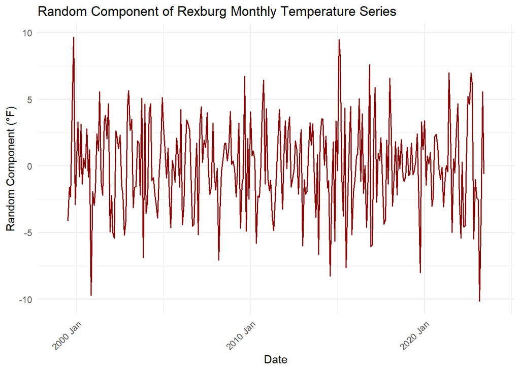

```r
random <- adjusted_data %>%
  mutate(random_comp = average_daily_high_temp - m_hat - s_adjusted_means)

# Step 2: Plot the random component series
ggplot(random, aes(x = year_month, y = random_comp)) +
  geom_line(color = "darkred", size = 0.7) +  # Plot the random component as a red line
  labs(title = "Random Component of Rexburg Monthly Temperature Series",
       x = "Date",
       y = "Random Component (°F)") +
  theme_minimal() +
  theme(axis.text.x = element_text(angle = 45, hjust = 1))
```

### Question 4: Additive Decomposition - R’s Decompose (15)

#### a) Please use additive decomposition model described in the Time Series notebook to decompose the Rexburg Monthly Temperature Series. Plot the algorithm’s output.

**Answer**

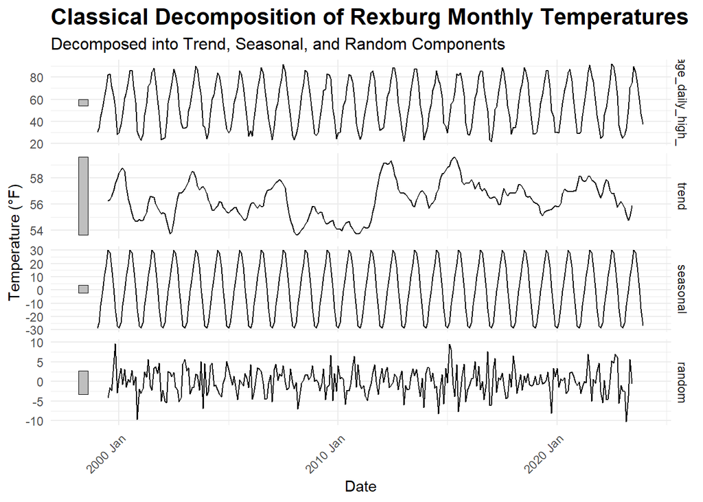

```r
rex_decomp <- monthly_tsibble |>
  model(feasts::classical_decomposition(average_daily_high_temp, type = "add")) |>
  components()

# Plot the decomposition components with appropriate labels
autoplot(rex_decomp) +
  labs(
    title = "Classical Decomposition of Rexburg Monthly Temperatures",
    subtitle = "Decomposed into Trend, Seasonal, and Random Components",
    x = "Date",
    y = "Temperature (°F)"
  ) +
  theme_minimal() +
  theme(
    plot.title = element_text(size = 16, face = "bold"),      # Make the title stand out
    plot.subtitle = element_text(size = 12),                 # Slightly smaller subtitle
    axis.text.x = element_text(angle = 45, hjust = 1)
  )
```

#### b) You can also decompose without aggregating the data series. The following code completes the additive decomposition with the original data set. Please use AI to comment and explain how to accomplish the task. Replace the code below with the fully explained code.

```r
# Weather data for Rexburg
daily_tsibble <- rio::import("https://byuistats.github.io/timeseries/data/rexburg_weather.csv") |>
  mutate(year_month_day = ymd(dates)) |>
  select(-imputed, -dates) |>
  # as_tibble() |>
  as_tsibble(index = year_month_day)

daily_tsibble %>% head

daily_decompose <- daily_tsibble  |>
  model(feasts::classical_decomposition(rexburg_airport_high ~ season(365.25),
                                        type = "add"))  |>
  components()


daily_decompose |> autoplot(.vars = random)
```

##### Commented

```r
# Import weather data for Rexburg from a CSV file hosted online.
daily_tsibble <- rio::import("https://byuistats.github.io/timeseries/data/rexburg_weather.csv") |>
  # Convert the 'dates' column to a proper date format using the `ymd()` function.
  mutate(year_month_day = ymd(dates)) |>
  # Remove the 'imputed' and original 'dates' columns.  We're using the new date column.
  select(-imputed, -dates) |>
  # Convert the data frame to a tsibble object, specifying 'year_month_day' as the time index.
  # This is crucial for time series analysis functions to work correctly.  A tsibble is a special
  # data frame for time series analysis.  It enforces a regular time index, which is important for many time series operations.
  as_tsibble(index = year_month_day)


# Display the first few rows of the tsibble to inspect the data.
daily_tsibble %>% head()
```

```
# A tsibble: 6 x 2 [1D]
  rexburg_airport_high year_month_day
                 <int> <date>
1                   30 1999-01-02
2                   25 1999-01-03
3                   26 1999-01-04
4                   29 1999-01-05
5                   32 1999-01-06
6                   31 1999-01-07
```

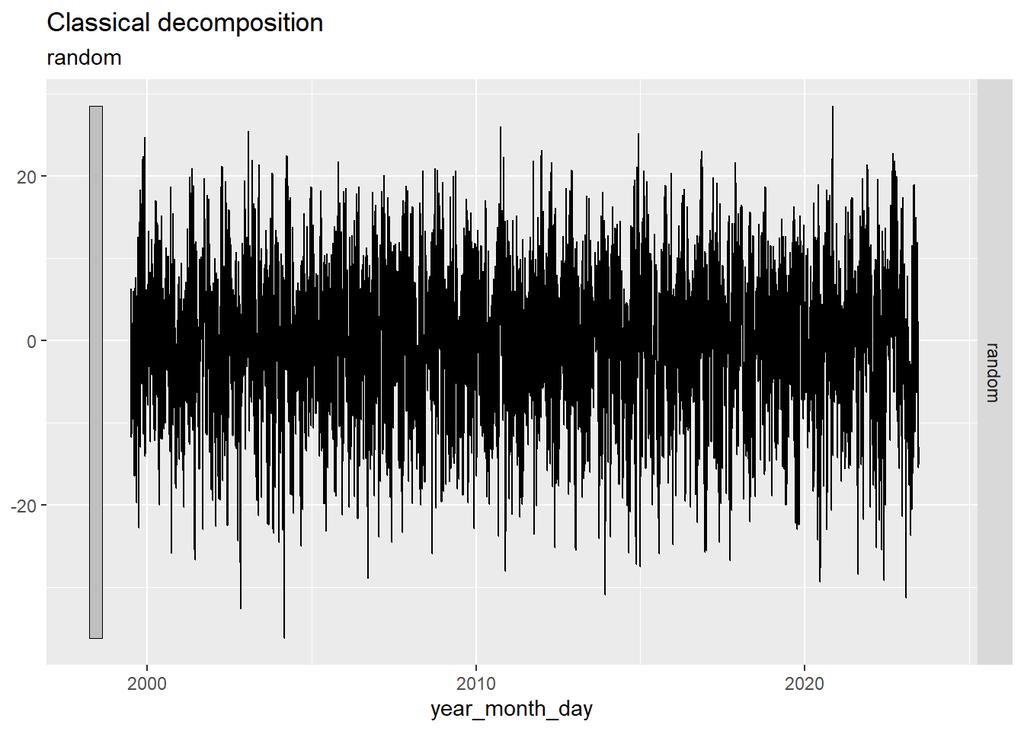

```r
# Decompose the time series into its components: trend, seasonality, and remainder.
daily_decompose <- daily_tsibble  |>
  # Fit a classical decomposition model to the 'rexburg_airport_high' variable (daily high temperatures).
  # `classical_decomposition()` function from the `feasts` package is used for this purpose.
  #   - `season(365.25)` specifies the length of the seasonal period (365.25 days for a year, accounting for leap years).
  #   - `type = "add"` indicates that an additive decomposition model should be used (Trend + Seasonality + Remainder = Observed).
  # An additive model is appropriate when the magnitude of the seasonal fluctuations does not change with the level of the series.  If
  # the seasonal fluctuations change with the level of the series, a multiplicative model would be more appropriate.
  model(feasts::classical_decomposition(rexburg_airport_high ~ season(365.25), type = "add"))  |>
  # Extract the decomposed components (trend, seasonality, and remainder) from the model.
  components()


# Plot the 'random' component (remainder) of the decomposition.  The remainder is what's left
# after the trend and seasonality have been removed.  It should ideally be random noise, centered
# around zero, with no obvious patterns.  If there are patterns in the remainder, it suggests
# that the model has not captured all of the structure in the data.
daily_decompose |> autoplot(.vars = random)
```

```r
# You could also plot other components:
# daily_decompose |> autoplot(.vars = trend)    # Plot the trend component.
# daily_decompose |> autoplot(.vars = season_year) # Plot the seasonal component.
# daily_decompose |> autoplot()  # Plot all components and the original data.
```

### Question 5: Seasonally Adjusted Series - Analysis (20 points)

#### a) Justify why we use the additive decomposition model to seasonally adjust the Rexburg Daily Temperature series.

**Answer**

There are various reasons why we use the additive decomposition model to seasonally adjust the rexburg daily temperatures. The first reason being the nature of the data with the season fluctuations being constant over time. In other words, the size of the seasonal effect ie: (the difference between the summer highs and winter lows) does not change as the trend changes. For example, if, on average, summer highs are 90°F and winter lows are 30°F, these differences will remain fairly consistent over time, even if there is a gradual warming trend that pushes both summer and winter temperatures higher. For instance, if the trend increases by 5°F, both summer highs and winter lows increase by roughly 5°F, but the seasonal gap between summer and winter (about 60°F) stays the same.

As in contrast to a multiplicative model, the seasonal fluctuations change in proportion to the trend. As the trend increases or decreases, the magnitude of the seasonal variation also increases or decreases. It is best used when the seasonal effect is multiplied by the trend.

In the Rexburg weather data, the difference between the hottest and coldest days of the year does not grow larger or smaller as overall temperatures change. Because this is constant, the seasonal variance aligns with the assumptions of the additive model where the seasonal effect is independent of the trend and is added to the overall temperature.

#### b) You calculated the random component of the series using three different procedures. Are the random component series the same? Are there patterns that are similar across all the random component series? Propose an explanation for the commonalities.

**Answer**

Given the random component being calculated in three different ways, the random component series are not the same. This is because the first & second methods use monthly aggregate (avg) data, while the third method uses daily data. The daily data will capture more short term flucutations of random noise, while the monthly will smooth out these short term effects, which will lead to a different random component.

There are similarities between the three procedures. They all aim to removing the long-term trend and recurring seasonal patterns to show the short-term variability or anomalies in the data. For example, an unusually cold or hot month (or day) will show up in all three random component series as a spike or dip, regardless of the method used. Furthermore, certain periods in the series may show more random fluctuations or weather patterns. Usually, transitions between weather seasons tend to have greater unpredictability in temperature, which would show in all three random component series. Lastly, any outliers in the series will show as sharp deviations across both procedures. The outliers are usually unrelated to long-term trend or seasonal cycles and will appear in the random component.

The commonalities in the random component series can all be explained by the fact that each method is trying to isolate the same underlying cause–the part of the data that can’t be explained by the trend or seasonal patterns. Removing the seasonal and trend components will leave behind the short-term fluctuations like a filter. While all methods are a little different in the way of calculating the random component, they will each capture the same general underlying pattern. In context of the Rexburg temperature data, they will lead to similar patterns in uncovering the random component or otherwise the unpredictable fluctuations in the temperature data.

## Rubric

[output not shown]